# animint2 gallery

viz.link

repo.link

source.link

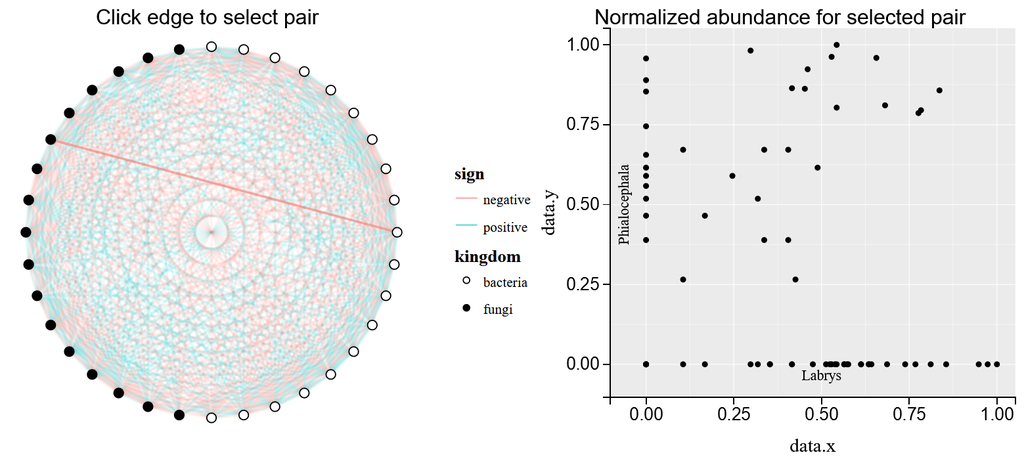

[bacteria_fungi_conservative visualization](https://github.com/tdhock/necromass-figure-one-network/tree/gh-pages)

[2023-10-27 23:58:42](https://github.com/tdhock/necromass/blob/main/figure-one-network.R)

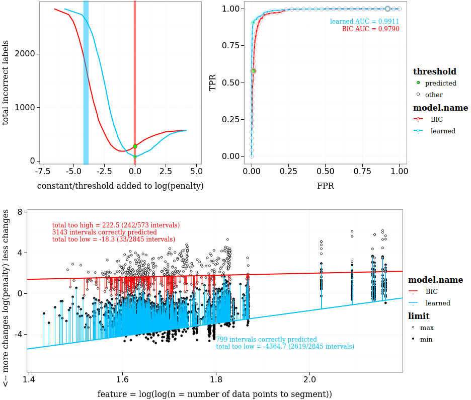

[BIC versus learned penalty in neuroblastoma data](https://github.com/tdhock/2023-08-interval-regression-BIC-vs-learned/tree/gh-pages)

[2023-11-05 06:21:24](https://github.com/tdhock/change-tutorial/blob/master/figure-regression-interactive.R)

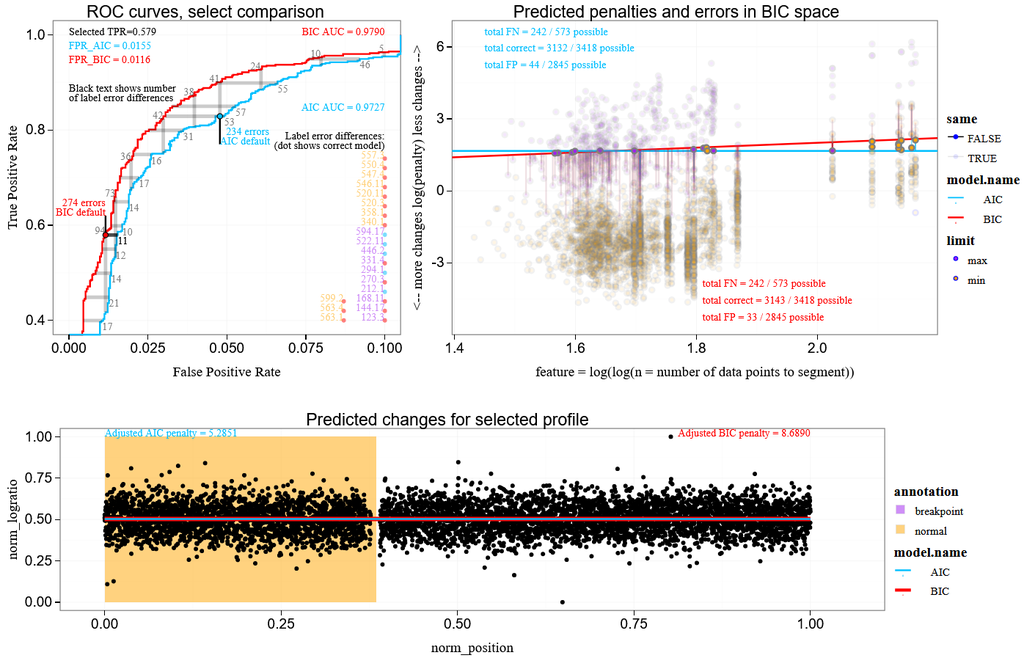

[AIC/BIC change-point detection comparison using ROC curves](https://github.com/tdhock/2023-11-interval-regression-differences/tree/gh-pages)

[2023-11-07 22:56:01](https://github.com/tdhock/change-tutorial/blob/master/figure-differences-interactive.R)

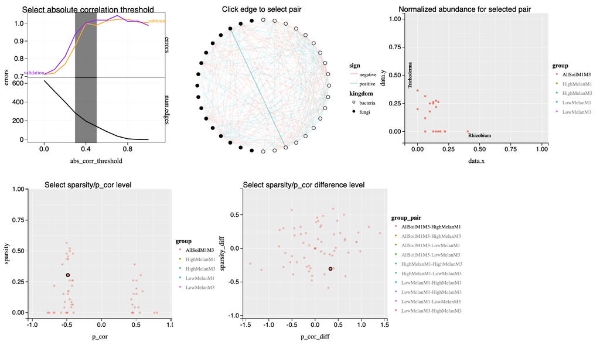

[bacteria_fungi_conservative visualization](https://github.com/EngineerDanny/EngineerDanny-necromass-figure-one-network/tree/gh-pages)

[2023-11-08 15:46:32](https://github.com/tdhock/necromass/blob/main/figure-one-network.Rmd)

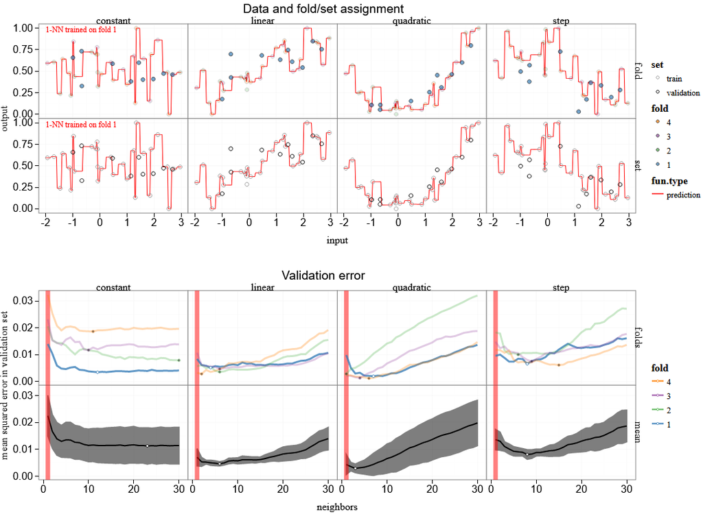

[4 fold cross-validation](https://github.com/tdhock/2019-01-nearest-neighbors-cross-validation/tree/gh-pages)

[2023-11-15 23:17:57](https://github.com/tdhock/cs499-spring2019/blob/master/2019-01-17-nearest-neighbors/viz-4folds.R)

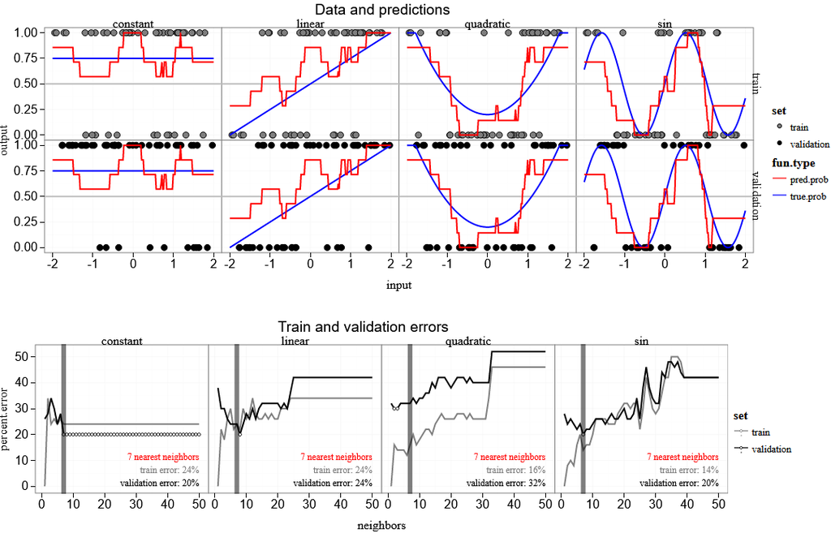

[Nearest neighbors algorithm for classification](https://github.com/tdhock/2019-01-nearest-neighbors-classification-1d/tree/gh-pages)

[2023-11-15 23:32:03](https://github.com/tdhock/cs499-spring2019/blob/master/2019-01-17-nearest-neighbors/viz-class-1d.R)

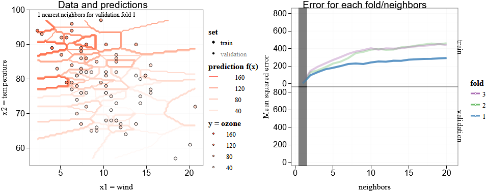

[Nearest neighbors for regression with 2D inputs](https://github.com/tdhock/2023-01-regression-2d/tree/gh-pages)

[2023-11-15 23:41:10](https://github.com/tdhock/cs499-spring2019/blob/master/2019-01-17-nearest-neighbors/viz-ozone-test.R)

Download this table: meta.csv

## Visualizations with missing meta-data

viz.link

repo.link

error

[tdhock/tdhock-figure-nnet-regression-degrees](https://tdhock.github.io/tdhock-figure-nnet-regression-degrees/)

[tdhock/tdhock-figure-nnet-regression-degrees](https://github.com/tdhock/tdhock-figure-nnet-regression-degrees/tree/gh-pages)

gh-pages branch of tdhock/tdhock-figure-nnet-regression-degrees should contain file named Capture.PNG (screenshot of data viz)

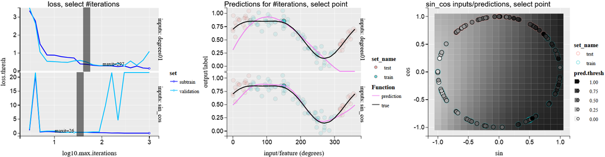

[tdhock/animint-figure-nnet-regression-degrees](https://github.com/tdhock/animint-figure-nnet-regression-degrees/tree/gh-pages)

plot.json file in gh-pages branch of tdhock/animint-figure-nnet-regression-degrees should have element named title which should be string describing the data viz

Download this table: error.csv

## Source code

- [This gallery repository](https://github.com/animint/gallery/tree/gh-pages),
- [`animint2::update_gallery()`](https://github.com/animint/animint2/blob/master/R/z_pages.R).